# Forcasting

```python
import pandas as pd
import numpy as np
import matplotlib.pyplot as plt
import seaborn as sns

import statsmodels.graphics.tsaplots as stg
import statsmodels.tsa.stattools as sts

from statsmodels.tsa.arima_model import ARMA
from statsmodels.tsa.arima.model import ARIMA

from statsmodels.tsa.seasonal import seasonal_decompose

from prophet import Prophet
from prophet.plot import add_changepoints_to_plot

from sklearn.metrics import mean_squared_error, mean_absolute_error
```

Import danych

```python
raw_csv=pd.read_csv("D:/Gry fabularne/Studia/Datax.csv")
```

```python
Data=raw_csv.copy()
```

```python
Data.head()
```

|  | Date | Temp; |
| --- | --- | --- |
| 0 | 1981-01-01 | 20.7; |
| 1 | 1981-01-02 | 17.9; |
| 2 | 1981-01-03 | 18.8; |
| 3 | 1981-01-04 | 14.6; |
| 4 | 1981-01-05 | 15.8; |

Zmiana Bledu formatowania

```python
Data["Temp;"]=Data["Temp;"].str.replace(";","")
```

```python
Data.rename(columns = {"Temp;":"Temp"}, inplace = True)
```

```python
Data = Data.replace('?0.2', '0.2')
Data = Data.replace('?0.8', '0.8')
Data = Data.replace('?0.1', '0.1')
Data['Temp'] = Data['Temp'].astype(float)
size=int(len(Data)*0.8)
Data_fp=Data.iloc[:size]
Data_fp_test=Data.iloc[size:]
```

```python
Data_fp.tail()
```

|  | Date | Temp |
| --- | --- | --- |
| 2915 | 1988-12-26 | 9.5 |
| 2916 | 1988-12-27 | 12.9 |
| 2917 | 1988-12-28 | 12.9 |
| 2918 | 1988-12-29 | 14.8 |
| 2919 | 1988-12-30 | 14.1 |

```python
Data_fp_test.head()
```

|  | Date | Temp |
| --- | --- | --- |
| 2920 | 1989-01-01 | 14.3 |
| 2921 | 1989-01-02 | 17.4 |
| 2922 | 1989-01-03 | 18.5 |
| 2923 | 1989-01-04 | 16.8 |
| 2924 | 1989-01-05 | 11.5 |

```python
Data.head()
```

|  | Date | Temp |
| --- | --- | --- |
| 0 | 1981-01-01 | 20.7 |
| 1 | 1981-01-02 | 17.9 |
| 2 | 1981-01-03 | 18.8 |
| 3 | 1981-01-04 | 14.6 |
| 4 | 1981-01-05 | 15.8 |

```python
Data.tail()
```

|  | Date | Temp |
| --- | --- | --- |
| 3645 | 1990-12-27 | 14.0 |
| 3646 | 1990-12-28 | 13.6 |
| 3647 | 1990-12-29 | 13.5 |
| 3648 | 1990-12-30 | 15.7 |
| 3649 | 1990-12-31 | 13.0 |

Badanie danych

```python
Data.describe()
```

|  | Temp |
| --- | --- |
| count | 3650.000000 |
| mean | 11.177753 |
| std | 4.071837 |
| min | 0.000000 |
| 25% | 8.300000 |
| 50% | 11.000000 |
| 75% | 14.000000 |
| max | 26.300000 |

```python
Data.isna().sum()
```

```
Date    0
Temp    0
dtype: int64
```

Podstawowa wizualizacja

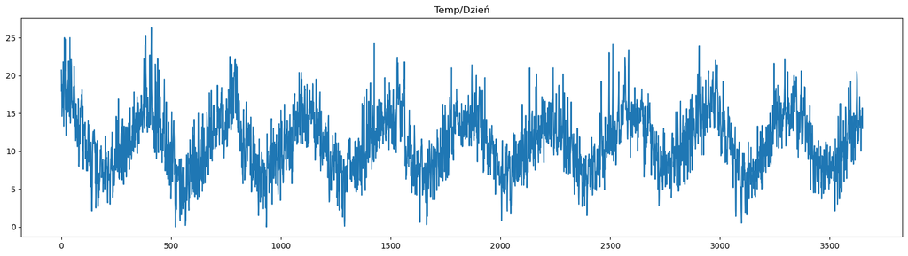

```python
Data.Temp.plot(figsize=(20,5),title="Temp/Dzień")
plt.show()
```

Obrobka Danych

```python
Data.Date=pd.to_datetime(Data.Date,dayfirst=True)
```

```python
Data.head()
```

|  | Date | Temp |
| --- | --- | --- |
| 0 | 1981-01-01 | 20.7 |
| 1 | 1981-01-02 | 17.9 |
| 2 | 1981-01-03 | 18.8 |
| 3 | 1981-01-04 | 14.6 |
| 4 | 1981-01-05 | 15.8 |

```python
Data.Date.describe()
```

```
C:\Users\Kuba Jędrzejczyk\AppData\Local\Temp\ipykernel_10764\3478658832.py:1: FutureWarning: Treating datetime data as categorical rather than numeric in `.describe` is deprecated and will be removed in a future version of pandas. Specify `datetime_is_numeric=True` to silence this warning and adopt …
  Data.Date.describe()
```

```
count                    3650
unique                   3650
top       1981-01-01 00:00:00
freq                        1
first     1981-01-01 00:00:00
last      1990-12-31 00:00:00
Name: Date, dtype: object
```

```python
Data.set_index("Date", inplace=True)
```

```python
Data.head()
```

| Date | Temp |
| --- | --- |
| 1981-01-01 | 20.7 |
| 1981-01-02 | 17.9 |
| 1981-01-03 | 18.8 |
| 1981-01-04 | 14.6 |
| 1981-01-05 | 15.8 |

```python
Data=Data.asfreq('d')
```

```python
Data.isna().sum()
```

```
Temp    2
dtype: int64
```

```python
Data.Temp=Data.Temp.fillna(method="ffill")
```

```python
Data.isna().sum()
```

```
Temp    0
dtype: int64
```

```python
size=int(len(Data)*0.8)
```

```python
df=Data.iloc[:size]
```

```python
df_test=Data.iloc[size:]
```

```python
df.tail()
```

| Date | Temp |
| --- | --- |
| 1988-12-26 | 9.5 |
| 1988-12-27 | 12.9 |
| 1988-12-28 | 12.9 |
| 1988-12-29 | 14.8 |
| 1988-12-30 | 14.1 |

```python
df_test.head()
```

| Date | Temp |
| --- | --- |
| 1988-12-31 | 14.1 |
| 1989-01-01 | 14.3 |
| 1989-01-02 | 17.4 |
| 1989-01-03 | 18.5 |
| 1989-01-04 | 16.8 |

Zbieranie informacji o naszym zbiorze danych

```python
sts.adfuller(Data.Temp) #Stationarity
```

```
(-4.440933664385148,
 0.0002510472415292601,
 20,
 3631,
 {'1%': -3.4321522387754775,
  '5%': -2.862336328589075,
  '10%': -2.567193897993964},
 16651.240027625234)
```

Ponieważ -4.440933<-3.432152 mamy duże prowdopodobieństwo "Stationarity"

0.00025104 oznacza że jest około 0,025% manas na nie odżucenieu NULL-a

Jest to dobra informacja oznaczająca że łatwo przeprowadzić na tych danych forcasting

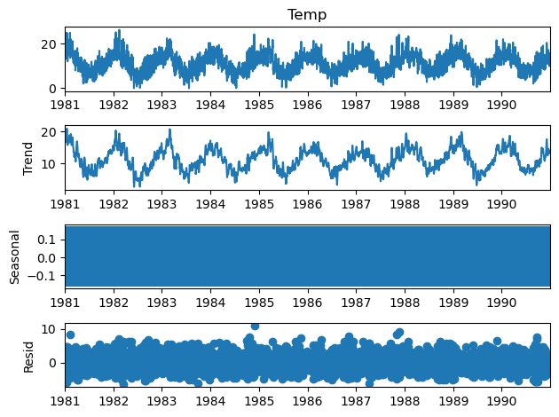

```python
s_dec_add=seasonal_decompose(Data.Temp, model="additive")
s_dec_add.plot()
plt.show()
```

Sprawdzanie sezonalnosci metodda additive

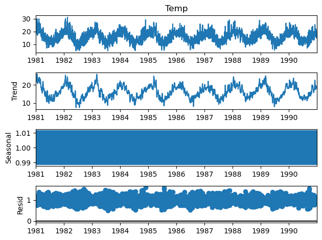

```python
s_dec_mul=seasonal_decompose(Data.Temp+5, model="multiplicative")
s_dec_mul.plot()
plt.show()
```

Sprawdzanie sezonalnosci metoda multiplicative, nie przyjmuje ona wartości negatywnych więc do każdej temperatury dodaliśmy 5 stopni

ACF-Autocorrelation

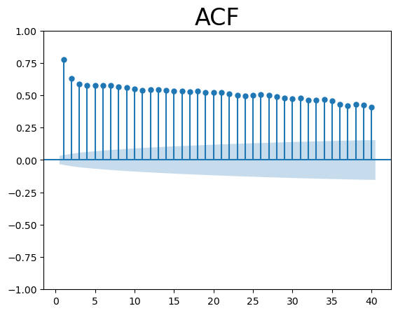

```python
stg.plot_acf(Data.Temp, lags=40, zero=False)
plt.title("ACF",size=24)
plt.show()
```

Jak widać nasz wykres jest zawsze wyżej niż zamalowane niebieskie pole

Świadczy to o dużym prawdopodobueństwem autokorelacji

Mówi to nam że wartości z poprzedniego okresu są dobrymi indykatorami wartości z przysłego okresu

Jak widać im większa odleglosc czasu pomiedzy naszymi danymi tym mniejsze prawdopodobienstwo

ze wartości z poprzedniego okresu są dobrymi indykatorami wartości z przysłego okresu

PACF- Partial Autocorrelation

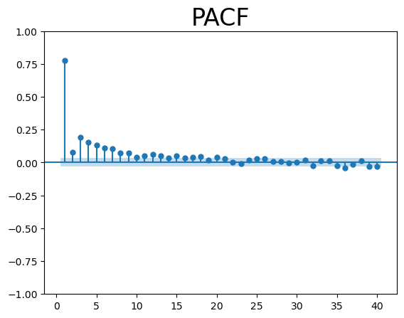

```python
stg.plot_pacf(Data.Temp, lags=40, zero=False, method=('ols'))
plt.title("PACF",size=24)
plt.show()
```

PACF w przeciwienstwie do ACF nie bierze pod uwage wszystkich wartosci pomiedzy

wybranymi danymi, tylko oblicza autokorelacje używając jednynie wartosci poczatkowej i koncowej

Jak widac znacznie trudniej jest przewidziec wynik za X dni jesli mamy tylko dostep

do temperatury zanotowenej X dni temu

Modelowanie

```python
Data_fp.rename(columns = {"Date":"ds"}, inplace = True)
Data_fp.rename(columns = {"Temp":"y"}, inplace = True)
Data_fp_test.rename(columns = {"Date":"ds"}, inplace = True)
Data_fp_test.rename(columns = {"Temp":"y"}, inplace = True)
```

```python
Data_fp.head()
```

|  | ds | y |
| --- | --- | --- |
| 0 | 1981-01-01 | 20.7 |
| 1 | 1981-01-02 | 17.9 |
| 2 | 1981-01-03 | 18.8 |
| 3 | 1981-01-04 | 14.6 |
| 4 | 1981-01-05 | 15.8 |

```python
Data_fp.tail()
```

|  | ds | y |
| --- | --- | --- |
| 2915 | 1988-12-26 | 9.5 |
| 2916 | 1988-12-27 | 12.9 |
| 2917 | 1988-12-28 | 12.9 |
| 2918 | 1988-12-29 | 14.8 |
| 2919 | 1988-12-30 | 14.1 |

```python
Data_fp_test.head()
```

|  | ds | y |
| --- | --- | --- |
| 2920 | 1989-01-01 | 14.3 |
| 2921 | 1989-01-02 | 17.4 |
| 2922 | 1989-01-03 | 18.5 |
| 2923 | 1989-01-04 | 16.8 |
| 2924 | 1989-01-05 | 11.5 |

```python
Data_fp_test.tail()
```

|  | ds | y |
| --- | --- | --- |
| 3645 | 1990-12-27 | 14.0 |
| 3646 | 1990-12-28 | 13.6 |
| 3647 | 1990-12-29 | 13.5 |
| 3648 | 1990-12-30 | 15.7 |
| 3649 | 1990-12-31 | 13.0 |

```python
m = Prophet()
m.fit(Data_fp)
```

```
22:58:07 - cmdstanpy - INFO - Chain [1] start processing
22:58:07 - cmdstanpy - INFO - Chain [1] done processing
```

```
<prophet.forecaster.Prophet at 0x1e06a4ea650>
```

```python
Data_fp_test_forcast=m.predict(Data_fp_test)
```

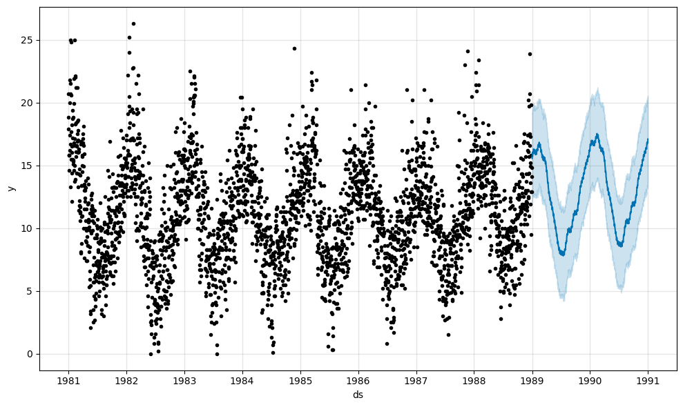

```python
fig=m.plot(Data_fp_test_forcast)
```

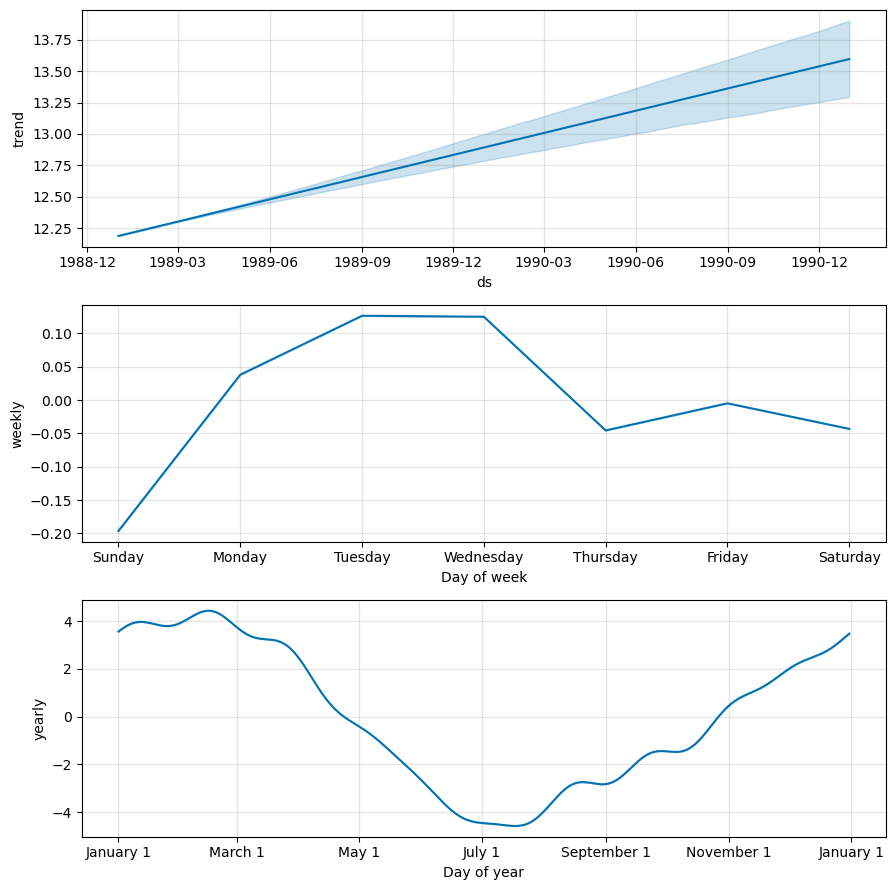

```python
fig=m.plot_components(Data_fp_test_forcast)
```

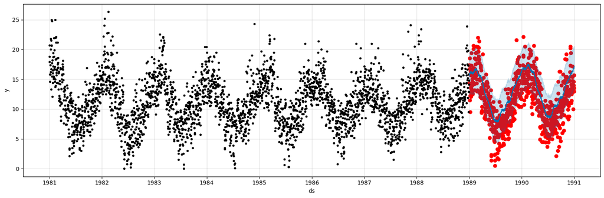

```python
f, ax = plt.subplots(figsize=(15, 5))
ax.scatter(pd.to_datetime(Data_fp_test.ds,dayfirst=True), Data_fp_test["y"], color="r")
fig = m.plot(Data_fp_test_forcast, ax=ax)
```

```python
np.sqrt(mean_squared_error(y_true=Data_fp_test["y"],
                   y_pred=Data_fp_test_forcast["yhat"]))
```

```
2.9289240923783173
```

```python
mean_absolute_error(y_true=Data_fp_test["y"],
                   y_pred=Data_fp_test_forcast["yhat"])
```

```
2.3814418110772393
```